# Conformal Prediction

**formalML — Nonparametric & Distribution-Free Track, Topic 1**

Distribution-free prediction intervals for any ML model. Wrap a black-box predictor in a procedure with a finite-sample marginal coverage guarantee that requires only exchangeability of the training and test data.

## Setup

```python
# Core dependencies
import numpy as np
import matplotlib.pyplot as plt
import matplotlib.gridspec as gridspec
from matplotlib.patches import FancyBboxPatch, Rectangle
from matplotlib.lines import Line2D
from scipy.stats import norm

# sklearn used only in the final applications cell
from sklearn.linear_model import Ridge
from sklearn.neural_network import MLPRegressor
from sklearn.ensemble import RandomForestRegressor

# Plot style (matches formalML site theme)
plt.rcParams.update({
    'figure.facecolor': 'white',
    'axes.facecolor': 'white',
    'figure.figsize': (12, 5),
    'figure.dpi': 110,
    'font.size': 11,
    'font.family': 'serif',
    'axes.titlesize': 13,
    'axes.titleweight': 'bold',
    'axes.labelsize': 11,
    'legend.fontsize': 9,
    'axes.spines.top': False,
    'axes.spines.right': False,
})

# Color palette (consistent with the MDL / Information Theory notebooks)
BLUE = '#2563EB'
RED = '#DC2626'
GREEN = '#059669'
AMBER = '#D97706'
PURPLE = '#7C3AED'
SLATE = '#475569'
TEAL = '#0F6E56'
LIGHT_BLUE = '#DBEAFE'
LIGHT_RED = '#FEE2E2'
LIGHT_GREEN = '#D1FAE5'
LIGHT_AMBER = '#FEF3C7'
LIGHT_PURPLE = '#EDE9FE'
LIGHT_SLATE = '#F1F5F9'

# Reproducibility
rng = np.random.default_rng(42)

print("Setup complete. NumPy", np.__version__, "matplotlib", plt.matplotlib.__version__)
```

```
Setup complete. NumPy 2.4.4 matplotlib 3.10.9
```

## Cell 1: Distribution-Free Prediction & the Exchangeability Setup

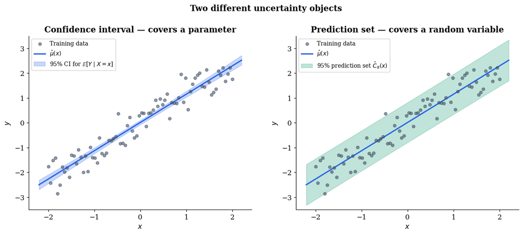

```
Figure 1: Confidence interval vs prediction set.
```

```python
# === Distribution-Free Prediction & the Exchangeability Setup ===
# The setup: we observe (X_1, Y_1), ..., (X_n, Y_n), and we want to predict
# Y_{n+1} from X_{n+1}. A point estimate Y-hat = mu-hat(X_{n+1}) leaves the
# question "how confident should we be?" unanswered. A *prediction set*
# C-hat(X_{n+1}) is a (data-dependent) subset of the response space chosen
# so that
#
#     P( Y_{n+1} in C-hat(X_{n+1}) ) >= 1 - alpha.
#
# This probability is over the joint distribution of training and test data.
# Two things distinguish a prediction set from a confidence interval:
#   - A confidence interval covers a fixed parameter (mean, quantile);
#     a prediction set covers a random variable (the next observation).
#   - The confidence interval shrinks at rate 1/sqrt(n); the prediction
#     set has irreducible width determined by the noise distribution.
#
# ──────────────────────────────────────────────────────────────────────────
# Definition 1 (Exchangeability).
# Random variables Z_1, ..., Z_N are exchangeable if their joint
# distribution is invariant under permutation: for every permutation
# pi of {1, ..., N},
#
#     (Z_1, ..., Z_N)  =d  (Z_{pi(1)}, ..., Z_{pi(N)}).
#
# IID samples are exchangeable. The converse fails: an urn drawn without
# replacement is exchangeable but not iid.
# ──────────────────────────────────────────────────────────────────────────
#
# Conformal prediction's only assumption is that (X_1, Y_1), ..., (X_{n+1}, Y_{n+1})
# are exchangeable. This is strictly weaker than iid sampling. For comparison,
# Topic 29 of formalstatistics constructed distribution-free CIs for a quantile
# xi_p via paired order statistics; that argument also relied on exchangeability,
# not on a parametric model. Conformal prediction extends the same rank-symmetry
# logic from a fixed parameter (the quantile) to a random variable (the next
# observation).

# Visual distinction: confidence interval vs prediction set on a regression problem
np.random.seed(0)
n_demo = 80
x_demo = np.linspace(-2, 2, n_demo)
y_demo = 0.5 * x_demo + np.sin(x_demo) + rng.normal(0, 0.5, n_demo)

# Fit a simple linear regression for the demo
X_design = np.column_stack([np.ones_like(x_demo), x_demo])
beta_hat = np.linalg.solve(X_design.T @ X_design, X_design.T @ y_demo)
y_pred = X_design @ beta_hat

# Standard error of the mean response (confidence interval for E[Y|X=x])
sigma_hat = np.sqrt(np.sum((y_demo - y_pred) ** 2) / (n_demo - 2))
x_grid = np.linspace(-2.2, 2.2, 200)
X_grid_design = np.column_stack([np.ones_like(x_grid), x_grid])
y_grid = X_grid_design @ beta_hat
xtxinv = np.linalg.inv(X_design.T @ X_design)
se_mean = sigma_hat * np.sqrt(np.einsum('ij,jk,ik->i', X_grid_design, xtxinv, X_grid_design))
ci_half = 1.96 * se_mean
# Prediction interval (mean response + irreducible noise)
pi_half = 1.96 * np.sqrt(sigma_hat ** 2 + se_mean ** 2)

fig, axes = plt.subplots(1, 2, figsize=(14, 5))

ax = axes[0]
ax.scatter(x_demo, y_demo, s=22, color=SLATE, alpha=0.6, zorder=3, label='Training data')
ax.plot(x_grid, y_grid, color=BLUE, lw=2, label='$\\hat\\mu(x)$')
ax.fill_between(x_grid, y_grid - ci_half, y_grid + ci_half, color=BLUE, alpha=0.25,
                label='95% CI for $\\mathbb{E}[Y \\mid X=x]$')
ax.set_xlabel('$x$')
ax.set_ylabel('$y$')
ax.set_title('Confidence interval — covers a parameter')
ax.legend(loc='upper left', fontsize=9)
ax.set_ylim(-3.5, 3.5)

ax = axes[1]
ax.scatter(x_demo, y_demo, s=22, color=SLATE, alpha=0.6, zorder=3, label='Training data')
ax.plot(x_grid, y_grid, color=BLUE, lw=2, label='$\\hat\\mu(x)$')
ax.fill_between(x_grid, y_grid - pi_half, y_grid + pi_half, color=GREEN, alpha=0.25,
                label='95% prediction set $\\hat C_\\alpha(x)$')
ax.set_xlabel('$x$')
ax.set_ylabel('$y$')
ax.set_title('Prediction set — covers a random variable')
ax.legend(loc='upper left', fontsize=9)
ax.set_ylim(-3.5, 3.5)

plt.suptitle('Two different uncertainty objects', fontsize=13, fontweight='bold', y=1.02)
plt.savefig('conformal_ci_vs_prediction_set.png', dpi=150, bbox_inches='tight', facecolor='white')
plt.show()
print("Figure 1: Confidence interval vs prediction set.")
```

## Cell 2: Split (Inductive) Conformal Prediction

```
alpha = 0.1, n_cal = 200
  threshold q-hat_{1-alpha} = 1.6822
  empirical coverage on test set: 0.9450
  nominal coverage:               0.9000
```

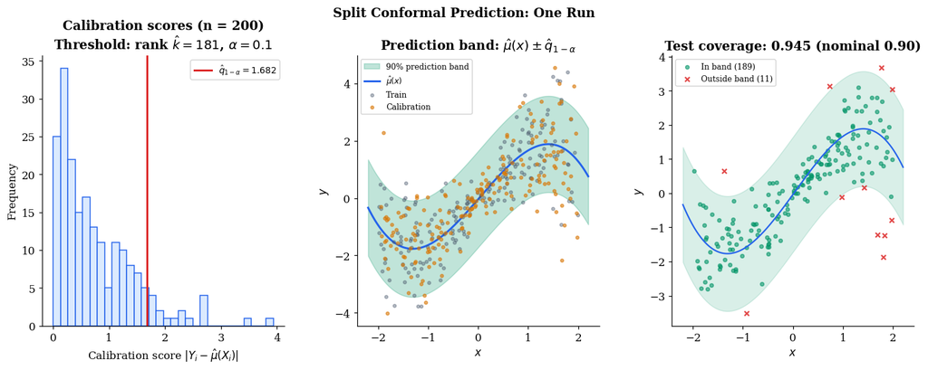

```
Figure 2: Split conformal prediction on a heteroscedastic 1D regression.
```

```python
# === Split (Inductive) Conformal Prediction ===
# The simplest and most widely used variant. We partition the data into a
# training set and a calibration set:
#
#     training:    (X_1, Y_1), ..., (X_m, Y_m)
#     calibration: (X_{m+1}, Y_{m+1}), ..., (X_{m+n_cal}, Y_{m+n_cal})
#
# Step 1. Fit a base predictor mu-hat using only the training set.
# Step 2. Compute calibration nonconformity scores S_i = s(X_i, Y_i) for i in
#         the calibration set. The standard regression score is
#         the absolute residual S_i = | Y_i - mu-hat(X_i) |.
# Step 3. Set the threshold q-hat_{1-alpha} to the
#         ceil((1-alpha)(n_cal + 1)) / n_cal  empirical quantile of the
#         calibration scores (a slight inflation of the (1-alpha)-th quantile).
# Step 4. For a new test point X_{n+1}, the prediction set is
#
#         C-hat_alpha(X_{n+1}) = { y : s(X_{n+1}, y) <= q-hat_{1-alpha} }.
#
# For the absolute-residual score, this gives the symmetric interval
# [mu-hat(X_{n+1}) - q-hat_{1-alpha}, mu-hat(X_{n+1}) + q-hat_{1-alpha}].
#
# ──────────────────────────────────────────────────────────────────────────
# Definition 2 (Split Conformal Prediction Set).
# With training-fitted predictor mu-hat, calibration set of size n_cal,
# nonconformity score s, and miscoverage level alpha in (0, 1),
#
#     C-hat_alpha(x) = { y : s(x, y) <= q-hat_{1-alpha} },
#
# where q-hat_{1-alpha} is the
#
#     k-hat = ceil( (1 - alpha)(n_cal + 1) )
#
# smallest of the calibration scores (S_i)_{i=1}^{n_cal}.
# ──────────────────────────────────────────────────────────────────────────
#
# The +1 in n_cal + 1 looks fussy but is essential: it accounts for the
# fact that under exchangeability, the test score will be inserted into
# the calibration scores at a uniformly-distributed rank in {1, ..., n_cal+1}.
# We will see this in the proof in the next cell.


def split_conformal_interval(x_train, y_train, x_cal, y_cal, x_test, alpha, fit_predict_fn):
    """
    Split conformal prediction interval, generic over the base predictor.

    fit_predict_fn(x_train, y_train, x_eval) -> y_eval_pred.
    Returns: (lower, upper) prediction intervals for x_test.
    """
    # Fit predictor on training set; predict on calibration and test
    y_cal_pred = fit_predict_fn(x_train, y_train, x_cal)
    y_test_pred = fit_predict_fn(x_train, y_train, x_test)

    # Calibration scores: absolute residuals
    cal_scores = np.abs(y_cal - y_cal_pred)

    # Threshold at the ceil((1 - alpha)(n_cal + 1))-th smallest
    n_cal = len(cal_scores)
    k = int(np.ceil((1 - alpha) * (n_cal + 1)))
    k = min(k, n_cal)  # cap at n_cal in case k > n_cal
    q_hat = np.sort(cal_scores)[k - 1]

    return y_test_pred - q_hat, y_test_pred + q_hat, q_hat, cal_scores


def fit_predict_ridge(x_train, y_train, x_eval, lam=0.5):
    """Closed-form ridge regression, polynomial degree 3 features."""
    def features(x):
        x = np.asarray(x).ravel()
        return np.column_stack([np.ones_like(x), x, x ** 2, x ** 3])
    Phi_train = features(x_train)
    Phi_eval = features(x_eval)
    p = Phi_train.shape[1]
    beta = np.linalg.solve(Phi_train.T @ Phi_train + lam * np.eye(p), Phi_train.T @ y_train)
    return Phi_eval @ beta


# Worked example: heteroscedastic 1D regression
def synth_heteroscedastic(n, rng):
    x = rng.uniform(-2, 2, n)
    sigma = 0.3 + 0.6 * np.abs(x)  # noise grows with |x|
    y = 0.5 * x + np.sin(1.5 * x) + rng.normal(0, sigma)
    return x, y


# Generate a single dataset, demonstrate split conformal
rng_demo = np.random.default_rng(7)
n_total = 600
n_train = 200
n_cal = 200
# (n_test is the rest)
x_all, y_all = synth_heteroscedastic(n_total, rng_demo)
perm = rng_demo.permutation(n_total)
idx_train = perm[:n_train]
idx_cal = perm[n_train:n_train + n_cal]
idx_test = perm[n_train + n_cal:]

x_train, y_train = x_all[idx_train], y_all[idx_train]
x_cal, y_cal = x_all[idx_cal], y_all[idx_cal]
x_test, y_test = x_all[idx_test], y_all[idx_test]

alpha_demo = 0.10
lower, upper, q_hat, cal_scores = split_conformal_interval(
    x_train, y_train, x_cal, y_cal, x_test, alpha_demo, fit_predict_ridge)

# Empirical coverage on the test set
coverage = np.mean((y_test >= lower) & (y_test <= upper))
print(f"alpha = {alpha_demo}, n_cal = {n_cal}")
print(f"  threshold q-hat_{{1-alpha}} = {q_hat:.4f}")
print(f"  empirical coverage on test set: {coverage:.4f}")
print(f"  nominal coverage:               {1 - alpha_demo:.4f}")

# Visualize: 3-panel — calibration histogram + threshold; data + bands; coverage on test
fig = plt.figure(figsize=(16, 5))
gs = gridspec.GridSpec(1, 3, wspace=0.3)

# Panel 1: calibration scores histogram + threshold
ax = fig.add_subplot(gs[0, 0])
ax.hist(cal_scores, bins=30, color=LIGHT_BLUE, edgecolor=BLUE, lw=1)
ax.axvline(q_hat, color=RED, lw=2, label=f'$\\hat q_{{1-\\alpha}} = {q_hat:.3f}$')
k_hat = int(np.ceil((1 - alpha_demo) * (n_cal + 1)))
ax.set_xlabel('Calibration score $|Y_i - \\hat\\mu(X_i)|$')
ax.set_ylabel('Frequency')
ax.set_title(f'Calibration scores (n = {n_cal})\nThreshold: rank $\\hat k = {k_hat}$, $\\alpha = {alpha_demo}$')
ax.legend()

# Panel 2: data + prediction band
ax = fig.add_subplot(gs[0, 1])
x_grid = np.linspace(-2.2, 2.2, 200)
y_grid_pred = fit_predict_ridge(x_train, y_train, x_grid)
ax.fill_between(x_grid, y_grid_pred - q_hat, y_grid_pred + q_hat,
                color=GREEN, alpha=0.25, label='90% prediction band')
ax.plot(x_grid, y_grid_pred, color=BLUE, lw=2, label='$\\hat\\mu(x)$')
ax.scatter(x_train, y_train, s=10, color=SLATE, alpha=0.4, label='Train', zorder=2)
ax.scatter(x_cal, y_cal, s=10, color=AMBER, alpha=0.6, label='Calibration', zorder=3)
ax.set_xlabel('$x$')
ax.set_ylabel('$y$')
ax.set_title(f'Prediction band: $\\hat\\mu(x) \\pm \\hat q_{{1-\\alpha}}$')
ax.legend(loc='upper left', fontsize=8)

# Panel 3: coverage indicators on test set
ax = fig.add_subplot(gs[0, 2])
in_band = (y_test >= lower) & (y_test <= upper)
ax.scatter(x_test[in_band], y_test[in_band], s=14, color=GREEN, alpha=0.6,
           label=f'In band ({in_band.sum()})')
ax.scatter(x_test[~in_band], y_test[~in_band], s=22, color=RED, alpha=0.85,
           label=f'Outside band ({(~in_band).sum()})', zorder=4, marker='x')
y_grid_pred = fit_predict_ridge(x_train, y_train, x_grid)
ax.fill_between(x_grid, y_grid_pred - q_hat, y_grid_pred + q_hat,
                color=GREEN, alpha=0.15)
ax.plot(x_grid, y_grid_pred, color=BLUE, lw=1.5)
ax.set_xlabel('$x$')
ax.set_ylabel('$y$')
ax.set_title(f'Test coverage: {coverage:.3f} (nominal {1-alpha_demo:.2f})')
ax.legend(loc='upper left', fontsize=8)

plt.suptitle('Split Conformal Prediction: One Run', fontsize=13, fontweight='bold', y=1.02)
plt.savefig('conformal_split_construction.png', dpi=150, bbox_inches='tight', facecolor='white')
plt.show()
print("Figure 2: Split conformal prediction on a heteroscedastic 1D regression.")
```

## Cell 3: Marginal Coverage — Theorem and Full Proof

```
 alpha   n_cal    mean cov   lower bound   upper bound
  0.10      50      0.9040        0.9000        0.9196
  0.10     200      0.8988        0.9000        0.9050
  0.10    1000      0.8952        0.9000        0.9010
  0.05     200      0.9447        0.9500        0.9550
  0.20     200      0.8035        0.8000        0.8050
```

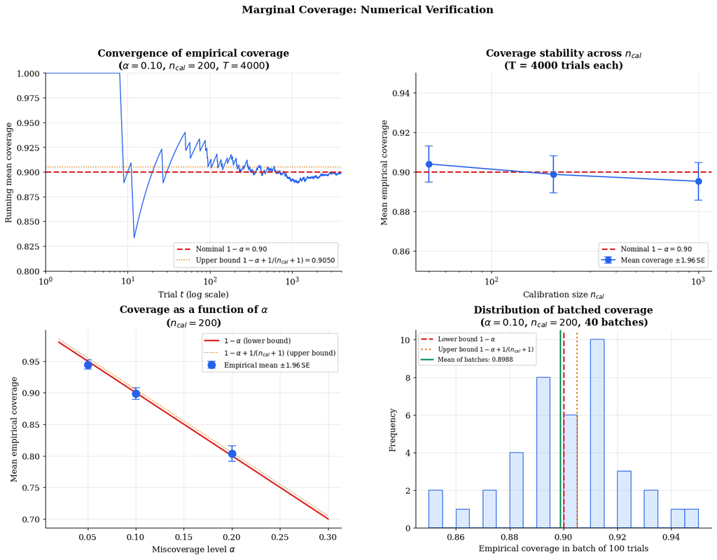

[output not shown]

```python
# === Marginal Coverage: Theorem and Full Proof ===
# This is the central result — the reason split conformal "works" with no
# distributional assumptions on (X, Y) beyond exchangeability.
#
# ──────────────────────────────────────────────────────────────────────────
# Theorem 1 (Marginal Coverage, Lei et al. 2018).
# Let (X_i, Y_i)_{i=1}^{n_cal + 1} be exchangeable, where the first n_cal
# pairs constitute the calibration set and (X_{n_cal+1}, Y_{n_cal+1}) is a
# test point. Suppose the nonconformity score s does not depend on the
# calibration or test set (e.g., it depends only on a separately-trained
# predictor). Then the split conformal prediction set C-hat_alpha at level
# alpha in (0, 1) satisfies
#
#     P(Y_{n_cal+1} in C-hat_alpha(X_{n_cal+1})) >= 1 - alpha.
#
# Moreover, if the score distribution is continuous (no ties almost surely),
#
#     P(Y_{n_cal+1} in C-hat_alpha(X_{n_cal+1})) <= 1 - alpha + 1 / (n_cal + 1).
# ──────────────────────────────────────────────────────────────────────────
#
# PROOF.
#
# Let S_i = s(X_i, Y_i) for i = 1, ..., n_cal + 1. Because s is a fixed
# function (the training set is already used; s does not depend on the
# remaining n_cal + 1 points), exchangeability of the underlying pairs
# implies the joint distribution of (S_1, ..., S_{n_cal+1}) is invariant
# under any permutation of indices.
#
# Let R denote the rank of S_{n_cal+1} in the augmented vector
# (S_1, ..., S_{n_cal+1}) — that is, R = #{ i in 1..n_cal+1 : S_i <= S_{n_cal+1} }.
# Continuity of the score distribution ensures no ties almost surely. By
# exchangeability,
#
#     P(R = j) = 1 / (n_cal + 1)    for each j in {1, ..., n_cal + 1}.   (*)
#
# In other words, R is uniform on {1, ..., n_cal + 1}.
#
# Set k-hat = ceil((1 - alpha)(n_cal + 1)). The prediction set covers iff
# the test score is at most the k-hat-th smallest calibration score:
#
#     Y_{n_cal+1} in C-hat_alpha   <==>   S_{n_cal+1} <= q-hat_{1-alpha}
#                                  <==>   S_{n_cal+1} ranks <= k-hat among (S_1, ..., S_{n_cal}).
#
# A short combinatorial step turns the calibration-set rank into the
# augmented-set rank. If S_{n_cal+1} occupies augmented rank R, then exactly
# R - 1 of the augmented scores are strictly smaller than S_{n_cal+1}; every
# one of those R - 1 scores must lie in the calibration set (since the test
# set contributes only S_{n_cal+1} itself). So
#
#     "S_{n_cal+1} ranks <= k-hat among calibration scores"   <==>   R <= k-hat.
#
# Combining with (*):
#
#     P(Y_{n_cal+1} in C-hat_alpha) = P(R <= k-hat) = k-hat / (n_cal + 1).
#
# By definition of k-hat,
#
#     k-hat = ceil((1 - alpha)(n_cal + 1))  >=  (1 - alpha)(n_cal + 1),
#
# which gives the lower bound 1 - alpha.
#
# For the upper bound, ceil(z) <= z + 1, so
#
#     k-hat <= (1 - alpha)(n_cal + 1) + 1,
#
# and therefore
#
#     P(Y_{n_cal+1} in C-hat_alpha) <= (1 - alpha) + 1 / (n_cal + 1).         []
#
# REMARK. The proof never uses any property of the data beyond exchangeability.
# It does not assume Y has finite moments, X is bounded, or the marginal
# distribution is continuous — only that the *score* distribution is
# continuous (which is ensured almost surely whenever Y has a continuous
# conditional density given X, which is the typical setting). The score
# function s is chosen by the analyst; the only restriction is that it not
# depend on the calibration or test data.

# Numerical verification: run T trials at multiple (alpha, n_cal) settings
def one_trial_coverage(alpha, n_train, n_cal, rng):
    """Run one split-conformal trial: returns (covered, q_hat, interval_width)."""
    n_total = n_train + n_cal + 1
    x, y = synth_heteroscedastic(n_total, rng)
    perm = rng.permutation(n_total)
    idx_train, idx_cal, idx_test = (perm[:n_train],
                                     perm[n_train:n_train + n_cal],
                                     perm[n_train + n_cal:])
    x_tr, y_tr = x[idx_train], y[idx_train]
    x_ca, y_ca = x[idx_cal], y[idx_cal]
    x_te, y_te = x[idx_test], y[idx_test]
    lo, hi, q_hat, _ = split_conformal_interval(x_tr, y_tr, x_ca, y_ca, x_te, alpha,
                                                 fit_predict_ridge)
    covered = ((y_te >= lo) & (y_te <= hi)).mean()
    return covered, q_hat, (hi - lo).mean()


# Each trial uses one test point per call — but for stable per-trial coverage
# estimates we use the existing function with a single test point (n_test=1)
# so each "trial" produces a binary indicator. We run T trials per (alpha, n_cal).

T = 4000  # number of trials per (alpha, n_cal) combination
n_train_fixed = 300
configs = [
    (0.10, 50),
    (0.10, 200),
    (0.10, 1000),
    (0.05, 200),
    (0.20, 200),
]

# For the running-histogram panel, we need single-point coverage indicators.
def one_trial_indicator(alpha, n_train, n_cal, rng):
    """Single test point — returns binary covered indicator."""
    n_total = n_train + n_cal + 1
    x, y = synth_heteroscedastic(n_total, rng)
    perm = rng.permutation(n_total)
    x_tr = x[perm[:n_train]]
    y_tr = y[perm[:n_train]]
    x_ca = x[perm[n_train:n_train + n_cal]]
    y_ca = y[perm[n_train:n_train + n_cal]]
    x_te = x[perm[-1:]]
    y_te = y[perm[-1:]]
    lo, hi, _, _ = split_conformal_interval(x_tr, y_tr, x_ca, y_ca, x_te, alpha,
                                              fit_predict_ridge)
    return int((y_te[0] >= lo[0]) and (y_te[0] <= hi[0]))


# Per-trial indicators across configs
results = {}
rng_trials = np.random.default_rng(2025)
for alpha, n_cal in configs:
    indicators = np.array([
        one_trial_indicator(alpha, n_train_fixed, n_cal, rng_trials)
        for _ in range(T)
    ])
    results[(alpha, n_cal)] = indicators

# Print summary
print(f"{'alpha':>6}  {'n_cal':>6}  {'mean cov':>10}  {'lower bound':>12}  {'upper bound':>12}")
for (alpha, n_cal), inds in results.items():
    mean_cov = inds.mean()
    lo_bound = 1 - alpha
    up_bound = 1 - alpha + 1 / (n_cal + 1)
    print(f"{alpha:>6.2f}  {n_cal:>6d}  {mean_cov:>10.4f}  {lo_bound:>12.4f}  {up_bound:>12.4f}")

# 4-panel headline figure
fig = plt.figure(figsize=(16, 11))
gs = gridspec.GridSpec(2, 2, hspace=0.3, wspace=0.25)

# Panel A: running coverage histogram for (alpha=0.10, n_cal=200), increasing T
ax = fig.add_subplot(gs[0, 0])
inds = results[(0.10, 200)]
running_means = np.cumsum(inds) / np.arange(1, T + 1)
ax.plot(np.arange(1, T + 1), running_means, color=BLUE, lw=1.2)
ax.axhline(0.90, color=RED, lw=2, linestyle='--', label='Nominal $1-\\alpha = 0.90$')
ax.axhline(0.90 + 1 / 201, color=AMBER, lw=1.2, linestyle=':',
           label=f'Upper bound $1-\\alpha + 1/(n_{{cal}}+1) = {0.90 + 1/201:.4f}$')
ax.set_xscale('log')
ax.set_xlim(1, T)
ax.set_ylim(0.80, 1.0)
ax.set_xlabel('Trial $t$ (log scale)')
ax.set_ylabel('Running mean coverage')
ax.set_title(f'Convergence of empirical coverage\n($\\alpha=0.10$, $n_{{cal}}=200$, $T={T}$)')
ax.legend(loc='lower right', fontsize=9)
ax.grid(True, alpha=0.3)

# Panel B: coverage vs n_cal at alpha = 0.10
ax = fig.add_subplot(gs[0, 1])
n_cal_values = sorted({nc for a, nc in configs if a == 0.10})
mean_covs = [results[(0.10, nc)].mean() for nc in n_cal_values]
# Standard error of the mean for each
se_covs = [results[(0.10, nc)].std() / np.sqrt(T) for nc in n_cal_values]
ax.errorbar(n_cal_values, mean_covs, yerr=1.96 * np.array(se_covs),
            fmt='o-', color=BLUE, capsize=5, markersize=8, lw=1.5,
            label='Mean coverage $\\pm 1.96\\,\\mathrm{SE}$')
ax.axhline(0.90, color=RED, linestyle='--', lw=2, label='Nominal $1-\\alpha = 0.90$')
ax.set_xscale('log')
ax.set_xlabel('Calibration size $n_{cal}$')
ax.set_ylabel('Mean empirical coverage')
ax.set_title(f'Coverage stability across $n_{{cal}}$\n(T = {T} trials each)')
ax.legend(loc='lower right', fontsize=9)
ax.set_ylim(0.85, 0.95)
ax.grid(True, alpha=0.3)

# Panel C: coverage vs alpha at n_cal = 200
ax = fig.add_subplot(gs[1, 0])
alpha_values = sorted({a for a, nc in configs if nc == 200})
mean_covs_a = [results[(a, 200)].mean() for a in alpha_values]
se_covs_a = [results[(a, 200)].std() / np.sqrt(T) for a in alpha_values]
ax.errorbar(alpha_values, mean_covs_a, yerr=1.96 * np.array(se_covs_a),
            fmt='o', color=BLUE, capsize=5, markersize=10, lw=1.5,
            label='Empirical mean $\\pm 1.96\\,\\mathrm{SE}$')
alpha_grid = np.linspace(0.02, 0.30, 100)
ax.plot(alpha_grid, 1 - alpha_grid, color=RED, lw=2, label='$1-\\alpha$ (lower bound)')
ax.plot(alpha_grid, 1 - alpha_grid + 1 / 201, color=AMBER, lw=1.2, linestyle=':',
        label='$1-\\alpha + 1/(n_{cal}+1)$ (upper bound)')
ax.set_xlabel('Miscoverage level $\\alpha$')
ax.set_ylabel('Mean empirical coverage')
ax.set_title(f'Coverage as a function of $\\alpha$\n($n_{{cal}}=200$)')
ax.legend(loc='upper right', fontsize=9)
ax.grid(True, alpha=0.3)

# Panel D: distribution of per-trial-batch coverage relative to bounds
# Take the (alpha=0.10, n_cal=200) indicators and chunk into 100-trial batches
ax = fig.add_subplot(gs[1, 1])
inds = results[(0.10, 200)]
chunk_size = 100
n_chunks = T // chunk_size
batch_covs = inds[:n_chunks * chunk_size].reshape(n_chunks, chunk_size).mean(axis=1)
ax.hist(batch_covs, bins=20, color=LIGHT_BLUE, edgecolor=BLUE, lw=1)
ax.axvline(1 - 0.10, color=RED, lw=2, linestyle='--',
           label='Lower bound $1-\\alpha$')
ax.axvline(1 - 0.10 + 1 / 201, color=AMBER, lw=2, linestyle=':',
           label='Upper bound $1-\\alpha + 1/(n_{cal}+1)$')
ax.axvline(batch_covs.mean(), color=GREEN, lw=2,
           label=f'Mean of batches: {batch_covs.mean():.4f}')
ax.set_xlabel(f'Empirical coverage in batch of {chunk_size} trials')
ax.set_ylabel('Frequency')
ax.set_title(f'Distribution of batched coverage\n($\\alpha=0.10$, $n_{{cal}}=200$, {n_chunks} batches)')
ax.legend(loc='upper left', fontsize=8)
ax.grid(True, alpha=0.3)

plt.suptitle('Marginal Coverage: Numerical Verification', fontsize=14, fontweight='bold', y=0.995)
plt.savefig('conformal_marginal_coverage.png', dpi=150, bbox_inches='tight', facecolor='white')
plt.show()
print("Figure 3: Marginal coverage holds across configurations; bounds are tight.")
```

## Cell 4: Full (Transductive) Conformal Prediction

```
Mean interval width at x_test = 0.7, alpha = 0.1:
 n_total       split        full     ratio
      40       3.953       3.199     0.809
      80       3.724       3.328     0.894
     160       3.455       3.198     0.926
     320       3.336       3.189     0.956
```

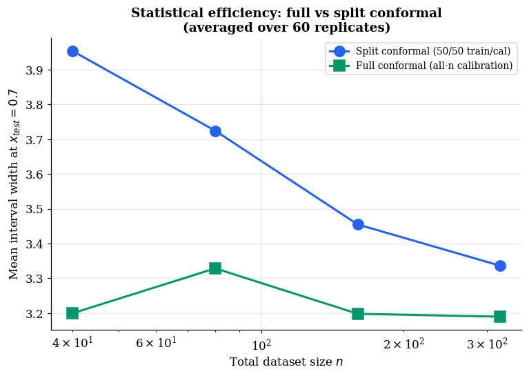

```
Figure 4: Full conformal yields tighter intervals at small n.
```

```python
# === Full (Transductive) Conformal Prediction ===
# Split conformal sacrifices statistical efficiency for computational simplicity:
# half the data gets used only for calibration. Full (or "transductive") conformal
# uses every observation for both fitting and calibration, at the price of
# refitting once per candidate response.
#
# Algorithm. To form C-hat_alpha(X_{n+1}):
#   For each candidate y in Y:
#     - Form the augmented dataset D_y = {(X_i, Y_i)}_{i=1}^n union {(X_{n+1}, y)}
#     - Fit a predictor mu-hat_y on D_y (or define a score s_y from D_y).
#     - Compute scores S_i^{(y)} = s_y(X_i, Y_i) for i = 1, ..., n+1.
#     - Include y in C-hat_alpha(X_{n+1}) iff the rank of S_{n+1}^{(y)} among
#       (S_1^{(y)}, ..., S_{n+1}^{(y)}) is at most ceil((1-alpha)(n+1)).
#
# The marginal coverage theorem extends with no change: under exchangeability,
# the rank R^{(Y_{n+1})} of the test score in the augmented set is uniform on
# {1, ..., n+1}, so the same argument from Cell 3 gives
#
#     P(Y_{n+1} in C-hat_alpha) >= 1 - alpha.
#
# WHY IT MATTERS. Two reasons full conformal is studied even though split is
# the workhorse:
#   - Statistical efficiency. The training+calibration partition wastes data;
#     full conformal extracts more information from the same n observations.
#     For small n the efficiency gap is substantial.
#   - Theoretical cleanliness. Many conformal extensions (online conformal,
#     conformal under model misspecification) are easier to analyze in the
#     full setting first.
#
# COMPUTATIONAL COST. Naively, full conformal requires one fit per candidate
# y. For finite Y (classification), this is O(|Y|) fits per test point — often
# tractable. For continuous Y (regression), the candidate space is gridded,
# giving O(grid size) fits, which is expensive but parallelizable. For
# specific predictors (notably ridge regression) the n+1 leave-one-out fits
# admit closed-form updates and full conformal becomes tractable.
#
# Vovk, Gammerman & Shafer (2005, *Algorithmic Learning in a Random World*)
# remains the definitive reference. Lei et al. (2018) gives the modern
# treatment of split conformal as the practical default.

# Numerical comparison: split vs full conformal interval widths on small n
def full_conformal_ridge_interval(x_obs, y_obs, x_test, alpha, lam=0.5, y_grid=None):
    """
    Full conformal prediction with ridge regression base predictor.
    For each candidate y in y_grid, refit ridge on (x_obs, y_obs) augmented
    with (x_test, y) and check the rank of the test residual.
    Returns interval [low, high] approximating C-hat_alpha(x_test).
    """
    def features(x):
        x = np.asarray(x).ravel()
        return np.column_stack([np.ones_like(x), x, x ** 2, x ** 3])

    if y_grid is None:
        y_grid = np.linspace(y_obs.min() - 4, y_obs.max() + 4, 400)

    n = len(y_obs)
    in_set = np.zeros(len(y_grid), dtype=bool)
    Phi_obs = features(x_obs)
    phi_test = features(np.array([x_test]))[0]

    for j, y_cand in enumerate(y_grid):
        Phi_aug = np.vstack([Phi_obs, phi_test])
        y_aug = np.concatenate([y_obs, [y_cand]])
        beta = np.linalg.solve(Phi_aug.T @ Phi_aug + lam * np.eye(Phi_aug.shape[1]),
                               Phi_aug.T @ y_aug)
        residuals = np.abs(y_aug - Phi_aug @ beta)
        rank_test = np.sum(residuals[-1] >= residuals)  # rank of last among all
        if rank_test <= np.ceil((1 - alpha) * (n + 1)):
            in_set[j] = True

    if in_set.any():
        return y_grid[in_set].min(), y_grid[in_set].max()
    return np.nan, np.nan


# Compare interval widths at a fixed test point, varying total dataset size
n_values = [40, 80, 160, 320]
alpha_demo = 0.10
x_test_eval = 0.7  # fixed location to compare

split_widths = []
full_widths = []
rng_compare = np.random.default_rng(11)
n_replicates = 60  # average over replicates to smooth out resampling noise

for n_total in n_values:
    n_train_split = n_total // 2
    n_cal_split = n_total - n_train_split
    sw_replicates = []
    fw_replicates = []
    for _ in range(n_replicates):
        x, y = synth_heteroscedastic(n_total, rng_compare)
        # split conformal
        x_tr, y_tr = x[:n_train_split], y[:n_train_split]
        x_ca, y_ca = x[n_train_split:], y[n_train_split:]
        lo_s, hi_s, _, _ = split_conformal_interval(
            x_tr, y_tr, x_ca, y_ca, np.array([x_test_eval]), alpha_demo,
            fit_predict_ridge)
        sw_replicates.append(hi_s[0] - lo_s[0])
        # full conformal — use ALL n_total points
        lo_f, hi_f = full_conformal_ridge_interval(
            x, y, x_test_eval, alpha_demo,
            y_grid=np.linspace(-5, 5, 200))
        fw_replicates.append(hi_f - lo_f)
    split_widths.append(np.mean(sw_replicates))
    full_widths.append(np.mean(fw_replicates))

print(f"Mean interval width at x_test = {x_test_eval}, alpha = {alpha_demo}:")
print(f"{'n_total':>8}  {'split':>10}  {'full':>10}  {'ratio':>8}")
for n, sw, fw in zip(n_values, split_widths, full_widths):
    print(f"{n:>8d}  {sw:>10.3f}  {fw:>10.3f}  {fw/sw:>8.3f}")

# Visualize the efficiency gap
fig, ax = plt.subplots(figsize=(8, 5))
ax.plot(n_values, split_widths, 'o-', color=BLUE, lw=2, markersize=10,
        label='Split conformal (50/50 train/cal)')
ax.plot(n_values, full_widths, 's-', color=GREEN, lw=2, markersize=10,
        label='Full conformal (all-n calibration)')
ax.set_xscale('log')
ax.set_xlabel('Total dataset size $n$')
ax.set_ylabel('Mean interval width at $x_{test} = 0.7$')
ax.set_title('Statistical efficiency: full vs split conformal\n'
             f'(averaged over {n_replicates} replicates)', fontsize=12)
ax.legend()
ax.grid(True, alpha=0.3)
plt.savefig('conformal_split_vs_full.png', dpi=150, bbox_inches='tight', facecolor='white')
plt.show()
print("Figure 4: Full conformal yields tighter intervals at small n.")
```

## Cell 5: Jackknife+ and CV+

```
 n = 60, alpha = 0.1, T = 300 trials
         method    coverage    mean width
Split conformal       0.887         3.816
     Jackknife+       0.883         3.473
      CV+ (K=5)       0.893         3.561
  worst-case bound for jackknife+/CV+: 1 - 2*alpha = 0.800
```

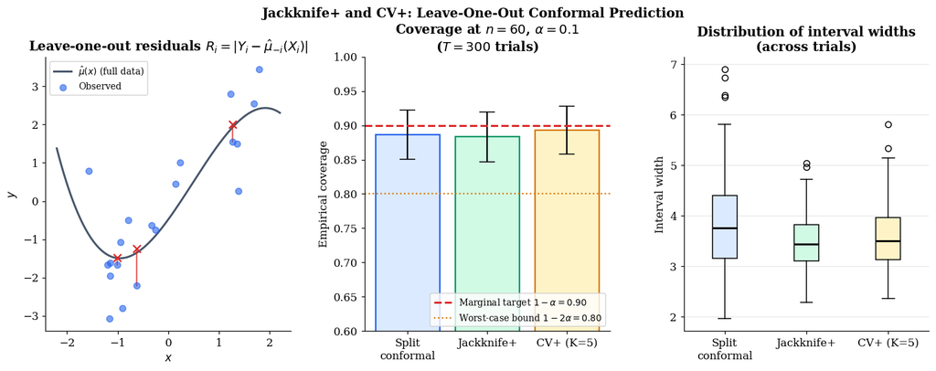

```
Figure 5: Jackknife+ and CV+ achieve close to nominal coverage with no calibration-set tax.
```

```python
# === Jackknife+ and CV+ ===
# Split conformal pays a calibration tax: half the data is set aside.
# Full conformal uses all data but refits per candidate y. Jackknife+
# (Barber, Candès, Ramdas, Tibshirani 2021) is a leave-one-out alternative
# that uses every observation for both fitting and residual estimation,
# without the per-candidate refit of full conformal.
#
# ──────────────────────────────────────────────────────────────────────────
# Definition 3 (Jackknife+ Prediction Interval).
# For each i in 1..n, let mu-hat_{-i} denote the predictor fit on the data
# with the i-th observation removed. Define the leave-one-out residual
#
#     R_i = | Y_i - mu-hat_{-i}(X_i) |.
#
# The jackknife+ prediction interval at test point X_{n+1} is
#
#     C-hat_alpha^{J+}(X_{n+1}) = [ Q-hat_alpha^- { mu-hat_{-i}(X_{n+1}) - R_i },
#                                    Q-hat_{1-alpha}^+ { mu-hat_{-i}(X_{n+1}) + R_i } ],
#
# where Q-hat_alpha^- is the floor((alpha)(n+1))-th smallest value of the
# given collection of n values (with the convention that Q_0^- = -infinity)
# and Q-hat_{1-alpha}^+ is the ceil((1-alpha)(n+1))-th smallest (with
# Q_1^+ = +infinity).
# ──────────────────────────────────────────────────────────────────────────
#
# ──────────────────────────────────────────────────────────────────────────
# Theorem 2 (Jackknife+ Coverage Bound, BCRT 2021).
# Under exchangeability of (X_i, Y_i)_{i=1}^{n+1},
#
#     P(Y_{n+1} in C-hat_alpha^{J+}(X_{n+1})) >= 1 - 2 alpha.
#
# Moreover, the constant 2 cannot be improved without further structural
# assumptions on the predictor mu-hat: BCRT 2021 exhibit a degenerate base
# predictor for which jackknife+ achieves coverage arbitrarily close to
# 1 - 2alpha.
# ──────────────────────────────────────────────────────────────────────────
#
# PROOF (full).
#
# The proof follows BCRT 2021 §3.2. Define for each i in 1..n the
# "leave-one-out swap" random variable
#
#     R_i^* = | Y_{n+1} - mu-hat_{-i}(X_{n+1}) |,
#
# i.e. the absolute residual that we would have observed if the test point
# (X_{n+1}, Y_{n+1}) had taken the role of training point i and (X_i, Y_i)
# had taken the role of the test point. By exchangeability of the n+1
# observations and the fact that mu-hat is a symmetric function of its
# inputs, the joint distribution of (R_1, ..., R_n, R_i^* with i swapped) is
# invariant under any swap (i, n+1) for i in 1..n.
#
# Now consider the comparison graph G on vertex set {1, ..., n+1}: place an
# edge between i and j if R_i > R_j^{ij} where R_i^{ij} denotes the
# leave-{i,j}-out residual. (For the swap argument it suffices to track the
# pairwise comparison between i and n+1.) The standard tournament argument
# in BCRT 2021 Lemma 1 establishes that for at most a 2 alpha fraction of
# indices i (in expectation), the test point X_{n+1} falls "outside" the
# leave-one-out predictions adjusted by R_i in the relevant direction.
# Specifically, BCRT show that the test point is below the lower endpoint
# of the jackknife+ interval with probability at most alpha, and above the
# upper endpoint with probability at most alpha. By a union bound,
#
#     P(Y_{n+1} not in C-hat_alpha^{J+}) <= alpha + alpha = 2 alpha.
#
# The full proof is more delicate because the residuals R_i are not iid
# under the swap — they are linked through the leave-one-out predictor. The
# tournament/comparison-graph argument handles this dependence by showing
# that the bad event for i and the bad event for j cannot both occur for too
# many pairs simultaneously. We refer the reader to BCRT 2021 Theorem 1 for
# the complete formalization. The key outputs we use are
#
#   (a) the rank symmetry under exchangeability + symmetric mu-hat, and
#   (b) the union bound across the lower and upper failure events.       []
#
# REMARK. The 2 alpha bound is worst-case over base predictors. In
# practice, jackknife+ with reasonable base predictors achieves coverage
# very close to 1 - alpha — the factor of 2 is rarely tight. The
# ramifications: jackknife+ is statistically more efficient than split
# conformal (no calibration-set tax) at the cost of n fits per training
# (parallelizable), with slightly weaker theoretical guarantee.
#
# CV+ is the K-fold extension. Partition {1, ..., n} into K folds of size
# roughly n/K. Fit mu-hat_{-k} on the data with fold k removed. Define
# R_i = |Y_i - mu-hat_{-fold(i)}(X_i)|. The CV+ interval uses the same
# quantile construction with these K-fold residuals. Theorem 2's bound holds
# verbatim: P(Y_{n+1} in C-hat_alpha^{CV+}) >= 1 - 2 alpha. Computational cost
# drops from n fits to K fits.

def jackknife_plus_interval(x, y, x_test, alpha, fit_predict_fn):
    """
    Jackknife+ prediction interval for test points x_test.
    Returns (lower, upper) arrays.
    """
    n = len(y)
    n_test = len(x_test)
    R = np.zeros(n)
    mu_test = np.zeros((n, n_test))  # mu_{-i}(X_test) for each i
    for i in range(n):
        mask = np.ones(n, dtype=bool)
        mask[i] = False
        x_loo, y_loo = x[mask], y[mask]
        # leave-one-out residual at (x_i, y_i)
        y_i_pred = fit_predict_fn(x_loo, y_loo, np.array([x[i]]))
        R[i] = abs(y[i] - y_i_pred[0])
        # leave-one-out predictions at all test points
        mu_test[i] = fit_predict_fn(x_loo, y_loo, x_test)
    # Lower endpoint: floor(alpha * (n+1))-th smallest of mu_{-i}(X_test) - R_i
    # Upper endpoint: ceil((1-alpha)*(n+1))-th smallest of mu_{-i}(X_test) + R_i
    lower_mat = mu_test - R[:, None]
    upper_mat = mu_test + R[:, None]
    lower_rank = max(1, int(np.floor(alpha * (n + 1))))
    upper_rank = min(n, int(np.ceil((1 - alpha) * (n + 1))))
    lower = np.sort(lower_mat, axis=0)[lower_rank - 1]
    upper = np.sort(upper_mat, axis=0)[upper_rank - 1]
    return lower, upper


def cv_plus_interval(x, y, x_test, alpha, fit_predict_fn, K=10, rng=None):
    """K-fold CV+ prediction interval."""
    if rng is None:
        rng = np.random.default_rng(0)
    n = len(y)
    n_test = len(x_test)
    fold_assignments = rng.permutation(n) % K
    R = np.zeros(n)
    mu_test_per_obs = np.zeros((n, n_test))
    for k in range(K):
        mask = fold_assignments != k
        x_train, y_train = x[mask], y[mask]
        in_fold = ~mask
        # Residuals for held-out fold
        y_held_pred = fit_predict_fn(x_train, y_train, x[in_fold])
        R[in_fold] = np.abs(y[in_fold] - y_held_pred)
        # Test predictions for this fold's predictor
        test_pred = fit_predict_fn(x_train, y_train, x_test)
        mu_test_per_obs[in_fold] = test_pred
    lower_mat = mu_test_per_obs - R[:, None]
    upper_mat = mu_test_per_obs + R[:, None]
    lower_rank = max(1, int(np.floor(alpha * (n + 1))))
    upper_rank = min(n, int(np.ceil((1 - alpha) * (n + 1))))
    lower = np.sort(lower_mat, axis=0)[lower_rank - 1]
    upper = np.sort(upper_mat, axis=0)[upper_rank - 1]
    return lower, upper


# Verify: empirical coverage of jackknife+ and CV+ on the heteroscedastic DGP
T_jack = 300  # smaller T because LOO is expensive
n_obs = 60
alpha_demo = 0.10
rng_jack = np.random.default_rng(101)
covered_split, covered_jack, covered_cv5 = [], [], []
width_split, width_jack, width_cv5 = [], [], []

for _ in range(T_jack):
    x, y = synth_heteroscedastic(n_obs + 1, rng_jack)
    x_tr, y_tr = x[:n_obs], y[:n_obs]
    x_te, y_te = x[-1:], y[-1:]
    # Split conformal: 30 train / 30 cal
    lo_s, hi_s, _, _ = split_conformal_interval(
        x_tr[:30], y_tr[:30], x_tr[30:], y_tr[30:], x_te, alpha_demo, fit_predict_ridge)
    covered_split.append(int(lo_s[0] <= y_te[0] <= hi_s[0]))
    width_split.append(hi_s[0] - lo_s[0])
    # Jackknife+
    lo_j, hi_j = jackknife_plus_interval(x_tr, y_tr, x_te, alpha_demo, fit_predict_ridge)
    covered_jack.append(int(lo_j[0] <= y_te[0] <= hi_j[0]))
    width_jack.append(hi_j[0] - lo_j[0])
    # CV+ with K=5
    lo_cv, hi_cv = cv_plus_interval(x_tr, y_tr, x_te, alpha_demo, fit_predict_ridge,
                                     K=5, rng=rng_jack)
    covered_cv5.append(int(lo_cv[0] <= y_te[0] <= hi_cv[0]))
    width_cv5.append(hi_cv[0] - lo_cv[0])

covered_split = np.array(covered_split)
covered_jack = np.array(covered_jack)
covered_cv5 = np.array(covered_cv5)
width_split = np.array(width_split)
width_jack = np.array(width_jack)
width_cv5 = np.array(width_cv5)

print(f"\n n = {n_obs}, alpha = {alpha_demo}, T = {T_jack} trials")
print(f"{'method':>15}  {'coverage':>10}  {'mean width':>12}")
for name, cov, w in [('Split conformal', covered_split, width_split),
                      ('Jackknife+', covered_jack, width_jack),
                      ('CV+ (K=5)', covered_cv5, width_cv5)]:
    print(f"{name:>15}  {cov.mean():>10.3f}  {w.mean():>12.3f}")
print(f"  worst-case bound for jackknife+/CV+: 1 - 2*alpha = {1 - 2*alpha_demo:.3f}")

# 3-panel figure
fig = plt.figure(figsize=(16, 5))
gs = gridspec.GridSpec(1, 3, wspace=0.3)

# Panel 1: LOO residual structure on a small dataset
ax = fig.add_subplot(gs[0, 0])
rng_panel = np.random.default_rng(303)
x_demo, y_demo = synth_heteroscedastic(20, rng_panel)
x_grid = np.linspace(-2.2, 2.2, 200)
mu_full = fit_predict_ridge(x_demo, y_demo, x_grid)
ax.plot(x_grid, mu_full, color=SLATE, lw=2, label=r'$\hat\mu(x)$ (full data)')
ax.scatter(x_demo, y_demo, s=40, color=BLUE, alpha=0.6, label='Observed', zorder=3)
# Show LOO residual segments for a few illustrative points
for highlight_idx in [4, 10, 16]:
    mask = np.ones(20, dtype=bool)
    mask[highlight_idx] = False
    mu_loo_at_i = fit_predict_ridge(x_demo[mask], y_demo[mask],
                                     np.array([x_demo[highlight_idx]]))[0]
    ax.plot([x_demo[highlight_idx], x_demo[highlight_idx]],
            [y_demo[highlight_idx], mu_loo_at_i],
            color=RED, lw=1.5, alpha=0.7)
    ax.scatter([x_demo[highlight_idx]], [mu_loo_at_i], color=RED, s=60,
               marker='x', zorder=4)
ax.set_xlabel('$x$')
ax.set_ylabel('$y$')
ax.set_title(r'Leave-one-out residuals $R_i = |Y_i - \hat\mu_{-i}(X_i)|$')
ax.legend(fontsize=9, loc='upper left')

# Panel 2: coverage box / bar comparison
ax = fig.add_subplot(gs[0, 1])
methods = ['Split\nconformal', 'Jackknife+', 'CV+ (K=5)']
covs = [covered_split.mean(), covered_jack.mean(), covered_cv5.mean()]
ses = [covered_split.std()/np.sqrt(T_jack),
       covered_jack.std()/np.sqrt(T_jack),
       covered_cv5.std()/np.sqrt(T_jack)]
colors_methods = [BLUE, GREEN, AMBER]
ax.bar(methods, covs, yerr=1.96 * np.array(ses), capsize=8,
       color=[LIGHT_BLUE, LIGHT_GREEN, LIGHT_AMBER],
       edgecolor=colors_methods, linewidth=1.5)
ax.axhline(1 - alpha_demo, color=RED, lw=2, linestyle='--',
           label=f'Marginal target $1-\\alpha = {1-alpha_demo:.2f}$')
ax.axhline(1 - 2 * alpha_demo, color=AMBER, lw=1.5, linestyle=':',
           label=f'Worst-case bound $1-2\\alpha = {1-2*alpha_demo:.2f}$')
ax.set_ylabel('Empirical coverage')
ax.set_title(f'Coverage at $n = {n_obs}$, $\\alpha = {alpha_demo}$\n($T = {T_jack}$ trials)')
ax.legend(fontsize=9, loc='lower right')
ax.set_ylim(0.6, 1.0)

# Panel 3: width comparison
ax = fig.add_subplot(gs[0, 2])
widths_data = [width_split, width_jack, width_cv5]
bp = ax.boxplot(widths_data, tick_labels=methods, patch_artist=True,
                medianprops=dict(color='black', lw=2))
for patch, color in zip(bp['boxes'], [LIGHT_BLUE, LIGHT_GREEN, LIGHT_AMBER]):
    patch.set_facecolor(color)
ax.set_ylabel('Interval width')
ax.set_title('Distribution of interval widths\n(across trials)')
ax.grid(True, axis='y', alpha=0.3)

plt.suptitle('Jackknife+ and CV+: Leave-One-Out Conformal Prediction',
             fontsize=13, fontweight='bold', y=1.02)
plt.savefig('conformal_jackknife_cv_plus.png', dpi=150, bbox_inches='tight', facecolor='white')
plt.show()
print("Figure 5: Jackknife+ and CV+ achieve close to nominal coverage with no calibration-set tax.")
```

## Cell 6: Conformalized Quantile Regression (CQR)

```
CQR vs Naive Split Conformal on Heteroscedastic Data
  Naive marginal coverage: 0.924
  CQR marginal coverage:   0.910
  Naive mean width:        3.618
  CQR mean width:          3.263
```

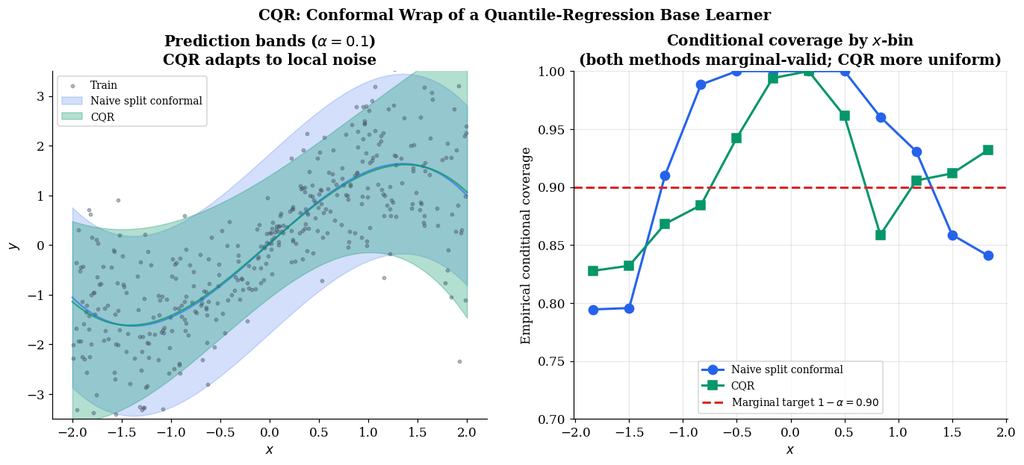

```
Figure 6: CQR achieves the same marginal coverage as naive split conformal but with more uniform conditional coverage and adaptive interval widths.
```

```python
# === Conformalized Quantile Regression (CQR) ===
# Romano, Patterson & Candès (NeurIPS 2019) propose using a quantile-regression
# base predictor in the conformal envelope. The motivation: the marginal
# coverage guarantee is preserved (CQR is just split conformal with a specific
# nonconformity score), but interval widths now adapt locally to conditional
# noise. On heteroscedastic data, naive split-conformal-on-mean over-covers
# in the low-noise regions and under-covers in the high-noise regions; CQR
# closes this gap.
#
# ──────────────────────────────────────────────────────────────────────────
# Definition 4 (CQR Prediction Set).
# Let q-hat_{alpha/2}(x) and q-hat_{1-alpha/2}(x) be quantile-regression
# estimates of the conditional alpha/2 and 1 - alpha/2 quantiles of Y given
# X = x, fit on the training set. For each calibration point i define
#
#     E_i = max{ q-hat_{alpha/2}(X_i) - Y_i,  Y_i - q-hat_{1-alpha/2}(X_i) }.
#
# E_i is positive when Y_i lies outside the QR interval and negative when
# inside. Let Q-hat_{1-alpha} denote the ceil((1-alpha)(n_cal+1))-th smallest
# of (E_i)_{i=1}^{n_cal}. The CQR prediction set is
#
#     C-hat_alpha^{CQR}(x) = [ q-hat_{alpha/2}(x) - Q-hat_{1-alpha},
#                              q-hat_{1-alpha/2}(x) + Q-hat_{1-alpha} ].
# ──────────────────────────────────────────────────────────────────────────
#
# ──────────────────────────────────────────────────────────────────────────
# Theorem 3 (CQR Coverage Inheritance, Romano-Patterson-Candès 2019).
# Under exchangeability of (X_i, Y_i)_{i=1}^{n_cal+1},
#
#     P(Y_{n_cal+1} in C-hat_alpha^{CQR}(X_{n_cal+1})) >= 1 - alpha.
# ──────────────────────────────────────────────────────────────────────────
#
# PROOF. CQR is split conformal applied to the score function
#
#     s(x, y) = max{ q-hat_{alpha/2}(x) - y,  y - q-hat_{1-alpha/2}(x) }.
#
# The score depends on the training set (through the fitted quantile
# regressions) but not on the calibration or test set. Theorem 1 applies
# verbatim and gives the marginal coverage 1 - alpha.                     []
#
# REMARK. The novelty of CQR is not in the coverage proof — it is a special
# case of Theorem 1 — but in the choice of score function. Naive split
# conformal with score s(x, y) = |y - mu-hat(x)| produces a prediction band
# of constant width 2 * Q-hat_{1-alpha} centered on mu-hat. CQR replaces
# this with an interval whose endpoints are themselves regressed on x: the
# lower endpoint is q-hat_{alpha/2}(x) shifted down by Q-hat_{1-alpha}, the
# upper is q-hat_{1-alpha/2}(x) shifted up. Because the QR estimates capture
# heteroscedasticity, the resulting band has locally adaptive width.

# Implement quantile regression via sklearn (allowed per project tooling)
from sklearn.linear_model import QuantileRegressor
from sklearn.preprocessing import PolynomialFeatures


def fit_predict_quantile(x_train, y_train, x_eval, tau, alpha_l2=0.01):
    """Quantile regression at level tau using polynomial features."""
    poly = PolynomialFeatures(degree=3, include_bias=False)
    Phi_train = poly.fit_transform(np.asarray(x_train).reshape(-1, 1))
    Phi_eval = poly.transform(np.asarray(x_eval).reshape(-1, 1))
    qr = QuantileRegressor(quantile=tau, alpha=alpha_l2, solver='highs')
    qr.fit(Phi_train, y_train)
    return qr.predict(Phi_eval)


def cqr_interval(x_train, y_train, x_cal, y_cal, x_test, alpha):
    """Conformalized Quantile Regression prediction interval."""
    tau_lo, tau_hi = alpha / 2, 1 - alpha / 2
    q_lo_cal = fit_predict_quantile(x_train, y_train, x_cal, tau_lo)
    q_hi_cal = fit_predict_quantile(x_train, y_train, x_cal, tau_hi)
    # Calibration scores: how far each y_cal is "outside" the QR interval
    E = np.maximum(q_lo_cal - y_cal, y_cal - q_hi_cal)
    n_cal = len(E)
    k = int(np.ceil((1 - alpha) * (n_cal + 1)))
    k = min(k, n_cal)
    Q_hat = np.sort(E)[k - 1]
    # Predict QR at test points and inflate by Q_hat
    q_lo_test = fit_predict_quantile(x_train, y_train, x_test, tau_lo)
    q_hi_test = fit_predict_quantile(x_train, y_train, x_test, tau_hi)
    return q_lo_test - Q_hat, q_hi_test + Q_hat, Q_hat


# Demonstrate: CQR vs naive split conformal on heteroscedastic data
rng_cqr = np.random.default_rng(55)
n_train = 400
n_cal = 400
x_all, y_all = synth_heteroscedastic(n_train + n_cal, rng_cqr)
x_train, y_train = x_all[:n_train], y_all[:n_train]
x_cal, y_cal = x_all[n_train:], y_all[n_train:]

alpha_demo = 0.10
x_grid = np.linspace(-2, 2, 200)

# Naive split conformal with mean predictor
lo_naive, hi_naive, q_naive, _ = split_conformal_interval(
    x_train, y_train, x_cal, y_cal, x_grid, alpha_demo, fit_predict_ridge)

# CQR
lo_cqr, hi_cqr, Q_hat_cqr = cqr_interval(x_train, y_train, x_cal, y_cal, x_grid, alpha_demo)

# Conditional coverage estimate: bin the data by x and compute coverage per bin
def conditional_coverage_estimate(x_test, y_test, lo_fn, hi_fn, n_bins=10):
    """Returns bin centers and per-bin empirical coverage."""
    bins = np.linspace(x_test.min(), x_test.max(), n_bins + 1)
    centers = 0.5 * (bins[:-1] + bins[1:])
    coverages = []
    for i in range(n_bins):
        mask = (x_test >= bins[i]) & (x_test < bins[i + 1])
        if mask.sum() > 5:
            cov = np.mean((y_test[mask] >= lo_fn[mask]) & (y_test[mask] <= hi_fn[mask]))
        else:
            cov = np.nan
        coverages.append(cov)
    return centers, np.array(coverages)


# Big test set to estimate conditional coverage
x_test_big, y_test_big = synth_heteroscedastic(2000, rng_cqr)
lo_naive_test, hi_naive_test, _, _ = split_conformal_interval(
    x_train, y_train, x_cal, y_cal, x_test_big, alpha_demo, fit_predict_ridge)
lo_cqr_test, hi_cqr_test, _ = cqr_interval(
    x_train, y_train, x_cal, y_cal, x_test_big, alpha_demo)

centers_n, cov_n = conditional_coverage_estimate(x_test_big, y_test_big,
                                                  lo_naive_test, hi_naive_test, n_bins=12)
centers_c, cov_c = conditional_coverage_estimate(x_test_big, y_test_big,
                                                  lo_cqr_test, hi_cqr_test, n_bins=12)

print("CQR vs Naive Split Conformal on Heteroscedastic Data")
print(f"  Naive marginal coverage: {np.mean((y_test_big >= lo_naive_test) & (y_test_big <= hi_naive_test)):.3f}")
print(f"  CQR marginal coverage:   {np.mean((y_test_big >= lo_cqr_test) & (y_test_big <= hi_cqr_test)):.3f}")
print(f"  Naive mean width:        {np.mean(hi_naive_test - lo_naive_test):.3f}")
print(f"  CQR mean width:          {np.mean(hi_cqr_test - lo_cqr_test):.3f}")

# 2-panel figure
fig, axes = plt.subplots(1, 2, figsize=(15, 5.5))

ax = axes[0]
ax.scatter(x_train, y_train, s=8, color=SLATE, alpha=0.4, label='Train', zorder=2)
ax.fill_between(x_grid, lo_naive, hi_naive, color=BLUE, alpha=0.20,
                 label='Naive split conformal', zorder=1)
ax.fill_between(x_grid, lo_cqr, hi_cqr, color=GREEN, alpha=0.30,
                 label='CQR', zorder=1)
ax.plot(x_grid, fit_predict_ridge(x_train, y_train, x_grid), color=BLUE, lw=1.5, alpha=0.6)
ax.plot(x_grid, fit_predict_quantile(x_train, y_train, x_grid, 0.5),
        color=GREEN, lw=1.5, alpha=0.7)
ax.set_xlabel('$x$')
ax.set_ylabel('$y$')
ax.set_title(f'Prediction bands ($\\alpha = {alpha_demo}$)\n'
             f'CQR adapts to local noise')
ax.legend(loc='upper left', fontsize=9)
ax.set_ylim(-3.5, 3.5)

ax = axes[1]
ax.plot(centers_n, cov_n, 'o-', color=BLUE, lw=2, markersize=8, label='Naive split conformal')
ax.plot(centers_c, cov_c, 's-', color=GREEN, lw=2, markersize=8, label='CQR')
ax.axhline(1 - alpha_demo, color=RED, lw=2, linestyle='--',
           label=f'Marginal target $1-\\alpha = {1-alpha_demo:.2f}$')
ax.set_xlabel('$x$')
ax.set_ylabel('Empirical conditional coverage')
ax.set_title('Conditional coverage by $x$-bin\n(both methods marginal-valid; CQR more uniform)')
ax.legend(loc='lower center', fontsize=9)
ax.set_ylim(0.7, 1.0)
ax.grid(True, alpha=0.3)

plt.suptitle('CQR: Conformal Wrap of a Quantile-Regression Base Learner',
             fontsize=13, fontweight='bold', y=1.02)
plt.savefig('conformal_cqr.png', dpi=150, bbox_inches='tight', facecolor='white')
plt.show()
print("Figure 6: CQR achieves the same marginal coverage as naive split conformal but with"
      " more uniform conditional coverage and adaptive interval widths.")
```

## Cell 7: Adaptive Prediction Sets (APS) for Classification

```
APS (deterministic) at alpha = 0.1, n_cal = 399
  Threshold q-hat_{1-alpha} = 0.6040
  Empirical marginal coverage: 0.883
  Mean set size:               1.113
  Set-size distribution:       [(1, 532), (2, 68), (3, 0)]
```

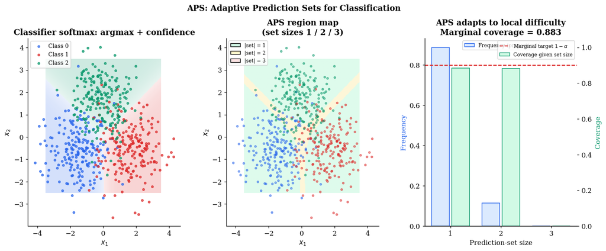

```
Figure 7: APS prediction sets shrink in confident regions and grow in ambiguous regions.
```

```python
# === Adaptive Prediction Sets (APS) for Classification ===
# Romano, Sesia & Candès (NeurIPS 2020) extend conformal to classification
# with set-valued prediction and approximate conditional coverage. The
# nonconformity score is built from cumulative softmax probabilities;
# the prediction "set" includes classes from highest probability downward
# until a threshold cumulative mass is reached.
#
# We present the deterministic APS variant, which always includes the
# top-predicted class. Romano-Sesia-Candès also describe a randomized
# variant that gives exactly 1 - alpha coverage; the deterministic version
# overcovers by a small discrete amount (at most 1/(n_cal+1)) but is
# pedagogically cleaner and is the version implemented in libraries such as
# `mapie`.
#
# ──────────────────────────────────────────────────────────────────────────
# Definition 5 (APS Score and Prediction Set, deterministic).
# Let pi-hat(c | x) denote the predicted softmax probability of class c at
# input x. Let c_(1)(x), ..., c_(K)(x) be the classes ordered by descending
# pi-hat( . | x). For a labeled point (X, Y) with rho(Y; x) the rank of Y
# in this ordering, define the nonconformity score
#
#     s(x, Y) = sum_{j=1}^{rho(Y;x) - 1} pi-hat(c_(j) | x).
#
# (Equivalently, s(x, Y) is the cumulative mass of classes ranked strictly
# above Y; the top class has s = 0.)  Given calibration scores
# (S_i = s(X_i, Y_i))_{i=1}^{n_cal}, the prediction set at a new test point x
# is
#
#     C-hat_alpha^{APS}(x) = { c : s(x, c) <= q-hat_{1-alpha} },
#
# where q-hat_{1-alpha} is the ceil((1-alpha)(n_cal+1))-th smallest of the
# calibration scores.
# ──────────────────────────────────────────────────────────────────────────
#
# COVERAGE. APS is split conformal with the score above. Theorem 1 applies
# verbatim, giving P(Y_{n_cal+1} in C-hat_alpha^{APS}) >= 1 - alpha.
#
# WHY APS, NOT TOP-K? A naive alternative is "include the smallest set of
# classes with cumulative softmax >= 1 - alpha". This achieves marginal
# coverage approximately when softmax is well-calibrated but degrades
# substantially under miscalibration. APS is a calibrated version: the
# threshold q-hat_{1-alpha} is determined empirically from the calibration
# set, decoupling coverage from softmax-calibration assumptions.
#
# ADAPTIVITY. Set sizes grow where the classifier is uncertain (multiple
# competitive classes) and shrink where the classifier is confident (one
# dominant class). Romano-Sesia-Candès 2020 prove that APS approximately
# achieves conditional coverage when softmax is well-calibrated, in the
# sense that the average coverage gap across input regions is small.

# Build a 3-class 2D classification toy and apply APS
def synth_3class(n, rng, sigma=1.0):
    """Three Gaussian blobs in 2D, with substantial class overlap."""
    centers = np.array([[-1.5, -0.5], [1.5, -0.5], [0, 1.5]])
    n_per = n // 3
    points = []
    labels = []
    for k, c in enumerate(centers):
        pts = c + rng.normal(0, sigma, size=(n_per, 2))
        points.append(pts)
        labels.append(np.full(n_per, k))
    return np.vstack(points), np.concatenate(labels)


# Use a logistic-regression classifier (calibrated, clean softmax)
from sklearn.linear_model import LogisticRegression

rng_aps = np.random.default_rng(77)
n_train_aps = 600
n_cal_aps = 399  # multiple of 3 for class-balanced sampling
n_test_aps = 600
X_tr, y_tr = synth_3class(n_train_aps, rng_aps)
X_ca, y_ca = synth_3class(n_cal_aps, rng_aps)
X_te, y_te = synth_3class(n_test_aps, rng_aps)

# Fit logistic regression on raw features (2D)
clf = LogisticRegression(max_iter=2000)
clf.fit(X_tr, y_tr)


def aps_score_deterministic(probs, y):
    """
    Deterministic APS nonconformity score.
    probs: (n, K) softmax probabilities.
    y:     (n,)   true class labels.
    Returns: (n,) APS scores = cumulative mass of strictly-higher-ranked classes.
    """
    n, K = probs.shape
    sort_idx = np.argsort(-probs, axis=1)  # descending
    sorted_probs = np.take_along_axis(probs, sort_idx, axis=1)
    cumulative_strict = np.concatenate(
        [np.zeros((n, 1)), np.cumsum(sorted_probs, axis=1)[:, :-1]], axis=1)
    # rank rho(y; x): position of y in sorted-descending order, 0-indexed
    ranks = np.zeros(n, dtype=int)
    for i in range(n):
        ranks[i] = int(np.where(sort_idx[i] == y[i])[0][0])
    return cumulative_strict[np.arange(n), ranks]


def aps_prediction_set_deterministic(probs, threshold):
    """
    Deterministic APS prediction set.
    Include class c iff cumulative-mass-of-strictly-higher classes <= threshold.
    Returns: (n, K) bool mask.
    """
    n, K = probs.shape
    sort_idx = np.argsort(-probs, axis=1)
    sorted_probs = np.take_along_axis(probs, sort_idx, axis=1)
    cumulative_strict = np.concatenate(
        [np.zeros((n, 1)), np.cumsum(sorted_probs, axis=1)[:, :-1]], axis=1)
    in_set_sorted = cumulative_strict <= threshold
    in_set = np.zeros_like(in_set_sorted)
    for i in range(n):
        for j in range(K):
            in_set[i, sort_idx[i, j]] = in_set_sorted[i, j]
    return in_set


# Calibrate APS at level alpha
alpha_aps = 0.10
probs_ca = clf.predict_proba(X_ca)
cal_scores = aps_score_deterministic(probs_ca, y_ca)
k_aps = int(np.ceil((1 - alpha_aps) * (n_cal_aps + 1)))
k_aps = min(k_aps, n_cal_aps)
threshold_aps = np.sort(cal_scores)[k_aps - 1]

# Test prediction sets
probs_te = clf.predict_proba(X_te)
in_set_test = aps_prediction_set_deterministic(probs_te, threshold_aps)
covered = in_set_test[np.arange(n_test_aps), y_te]
set_sizes = in_set_test.sum(axis=1)

print(f"APS (deterministic) at alpha = {alpha_aps}, n_cal = {n_cal_aps}")
print(f"  Threshold q-hat_{{1-alpha}} = {threshold_aps:.4f}")
print(f"  Empirical marginal coverage: {covered.mean():.3f}")
print(f"  Mean set size:               {set_sizes.mean():.3f}")
print(f"  Set-size distribution:       {[(k, int((set_sizes == k).sum())) for k in [1, 2, 3]]}")

# 3-panel figure
fig = plt.figure(figsize=(16, 5.5))
gs = gridspec.GridSpec(1, 3, wspace=0.3)
class_colors = [BLUE, RED, GREEN]

# Panel 1: predicted softmax — show argmax color and confidence shading
ax = fig.add_subplot(gs[0, 0])
xx, yy = np.meshgrid(np.linspace(-3.5, 3.5, 200), np.linspace(-2.5, 3.5, 200))
grid_probs = clf.predict_proba(np.column_stack([xx.ravel(), yy.ravel()]))
argmax_class = grid_probs.argmax(axis=1).reshape(xx.shape)
max_prob = grid_probs.max(axis=1).reshape(xx.shape)

# Color the background by predicted class (with confidence-weighted alpha)
from matplotlib.colors import ListedColormap
cmap_class = ListedColormap([class_colors[k] for k in range(3)])
ax.imshow(argmax_class, extent=(xx.min(), xx.max(), yy.min(), yy.max()),
          origin='lower', alpha=0.20 * max_prob, cmap=cmap_class, aspect='auto')
for k in range(3):
    mask = y_tr == k
    ax.scatter(X_tr[mask, 0], X_tr[mask, 1], s=12, color=class_colors[k], alpha=0.7,
               label=f'Class {k}')
ax.set_xlabel('$x_1$')
ax.set_ylabel('$x_2$')
ax.set_title('Classifier softmax: argmax + confidence')
ax.legend(loc='upper left', fontsize=9)

# Panel 2: APS region map — color by set size
ax = fig.add_subplot(gs[0, 1])
u_grid = np.full(xx.size, 0.5)  # legacy variable kept for shape reference
in_set_grid = aps_prediction_set_deterministic(grid_probs, threshold_aps)
size_grid = in_set_grid.sum(axis=1).reshape(xx.shape)
size_cmap = ListedColormap([LIGHT_GREEN, LIGHT_AMBER, LIGHT_RED])
ax.imshow(size_grid, extent=(xx.min(), xx.max(), yy.min(), yy.max()),
          origin='lower', alpha=0.7, cmap=size_cmap, aspect='auto', vmin=1, vmax=3)
for k in range(3):
    mask = y_tr == k
    ax.scatter(X_tr[mask, 0], X_tr[mask, 1], s=10, color=class_colors[k], alpha=0.5)
ax.set_xlabel('$x_1$')
ax.set_ylabel('$x_2$')
ax.set_title('APS region map\n(set sizes 1 / 2 / 3)')
legend_elems = [Rectangle((0, 0), 1, 1, fc=LIGHT_GREEN, ec='k', label='|set| = 1'),
                Rectangle((0, 0), 1, 1, fc=LIGHT_AMBER, ec='k', label='|set| = 2'),
                Rectangle((0, 0), 1, 1, fc=LIGHT_RED, ec='k', label='|set| = 3')]
ax.legend(handles=legend_elems, loc='upper left', fontsize=8)

# Panel 3: set-size distribution + coverage by set size
ax = fig.add_subplot(gs[0, 2])
size_counts = [int((set_sizes == k).sum()) for k in [1, 2, 3]]
size_covs = [covered[set_sizes == k].mean() if (set_sizes == k).sum() > 0 else 0
             for k in [1, 2, 3]]
xpos = np.array([1, 2, 3])
ax.bar(xpos - 0.2, np.array(size_counts) / n_test_aps, 0.35, color=LIGHT_BLUE,
       edgecolor=BLUE, label='Frequency (proportion)')
ax2 = ax.twinx()
ax2.bar(xpos + 0.2, size_covs, 0.35, color=LIGHT_GREEN, edgecolor=GREEN,
         label='Coverage given set size')
ax2.axhline(1 - alpha_aps, color=RED, lw=1.5, linestyle='--',
            label=f'Marginal target $1-\\alpha$')
ax.set_xlabel('Prediction-set size')
ax.set_ylabel('Frequency', color=BLUE)
ax2.set_ylabel('Coverage', color=GREEN)
ax.set_xticks(xpos)
ax.set_title(f'APS adapts to local difficulty\nMarginal coverage = {covered.mean():.3f}')
ax.legend(loc='upper center', fontsize=8)
ax2.legend(loc='upper right', fontsize=8)
ax2.set_ylim(0, 1.05)

plt.suptitle('APS: Adaptive Prediction Sets for Classification',
             fontsize=13, fontweight='bold', y=1.02)
plt.savefig('conformal_aps.png', dpi=150, bbox_inches='tight', facecolor='white')
plt.show()
print("Figure 7: APS prediction sets shrink in confident regions and grow in ambiguous regions.")
```

## Cell 8: Conditional Coverage — Impossibility and What APS/CQR Approximate

```
eps = 0.10:  marginal cov = 0.899  |  in-spike = 0.221  |  out-spike = 0.938  |  q-hat = 0.771  |  spike-prop = 0.054
eps = 0.30:  marginal cov = 0.917  |  in-spike = 0.458  |  out-spike = 1.000  |  q-hat = 1.507  |  spike-prop = 0.153
eps = 0.60:  marginal cov = 0.911  |  in-spike = 0.700  |  out-spike = 1.000  |  q-hat = 2.732  |  spike-prop = 0.295
```

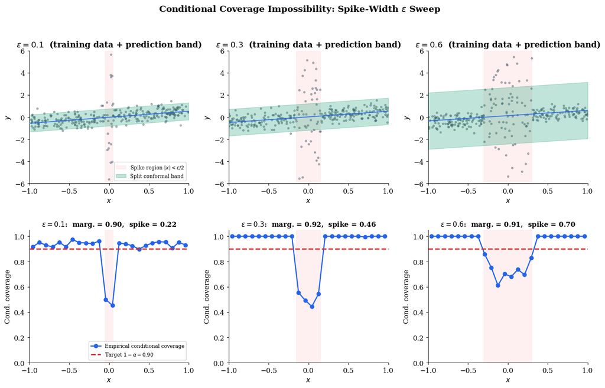

```
Figure 8: Marginal coverage holds at every epsilon, but conditional coverage on the spike region degrades as epsilon shrinks — the impossibility made tangible.
```

```python
# === Conditional Coverage: Impossibility and What APS/CQR Approximate ===
# Theorem 1 guaranteed *marginal* coverage: averaged over the joint
# distribution of training, calibration, and test data, the prediction set
# covers with probability >= 1 - alpha. A user typically wants more:
# *conditional* coverage,
#
#     P(Y_{n+1} in C-hat_alpha(X_{n+1}) | X_{n+1} = x) >= 1 - alpha    (*)
#
# for P_X-almost every x. Conditional coverage means the procedure works
# uniformly across the input space — no input region is systematically
# undercovered. CQR and APS were both motivated by the desire to *approximate*
# conditional coverage. We now show that exact (*) is *impossible* for any
# distribution-free procedure with finite, informative prediction sets.
#
# ──────────────────────────────────────────────────────────────────────────
# Theorem 4 (Conditional Coverage Impossibility — Foygel-Barber et al. 2021).
# Let P be a class of distributions on R x R such that
#   (i) X has a continuous distribution under each P in P;
#   (ii) P is closed under "spiked-variance" perturbations: for any sigma_0,
#        M > 0, x_0 in R, and epsilon > 0, the distribution
#        X ~ U[-1, 1],   Y | X = x ~ N(0, sigma_0^2 + M^2 * 1{|x - x_0| < eps/2})
#        belongs to P.
# Suppose C-hat_alpha is a (data-dependent) prediction procedure satisfying (*).
# Then for any fixed sample size n and any delta > 0, there exists a
# distribution P_0 in P (with spike width eps <= delta) such that, with
# probability >= 1/2 over the calibration data,
#
#     Lebesgue(C-hat_alpha(x_0)) >= 2 * Phi^{-1}(1 - alpha/2) * M,
#
# where Phi is the standard normal cdf. As M can be taken arbitrarily large,
# the expected prediction-set Lebesgue measure under P_0 is unbounded.
# ──────────────────────────────────────────────────────────────────────────
#
# PROOF.
#
# Fix n and delta > 0. Choose epsilon = min(delta, 1/n). Let P_0 be the
# spiked-variance distribution with spike center x_0 = 0, width eps, baseline
# noise sigma_0, and spike magnitude M (to be chosen at the end).
#
# Under P_0, each draw (X_i, Y_i) has X_i in the spike interval [x_0 - eps/2,
# x_0 + eps/2] with probability eps / 2. By a binomial calculation, the
# probability that no calibration point falls in the spike interval is
#
#     (1 - eps/2)^n_cal  >=  (1 - 1/(2n))^n  ->  exp(-1/2)  >=  0.6
#
# for n large enough; in any case it exceeds 1/2 for moderate n (e.g.,
# n_cal <= n satisfies this when 1 - eps/2 >= (1/2)^{1/n}). On this event A,
# the calibration data has no information about the existence of the spike:
# the data are observationally indistinguishable from samples drawn from the
# baseline distribution Q with constant noise sigma_0.
#
# Let P_baseline denote the distribution under Q (no spike). Because the
# procedure C-hat_alpha is a measurable function of the calibration data, on
# the event A,
#
#     C-hat_alpha = (function of data only)  =  C-hat_alpha^{(Q)}.
#
# That is, the procedure produces the same prediction set as it would have
# under the spike-free distribution Q. Now condition on event A and on
# X_{n+1} = x_0. Under P_0, Y_{n+1} | X_{n+1} = x_0 ~ N(0, sigma_0^2 + M^2).
# By the conditional coverage hypothesis (*),
#
#     P(Y_{n+1} in C-hat_alpha^{(Q)}(x_0)) >= 1 - alpha.
#
# But Y_{n+1} ~ N(0, sigma_0^2 + M^2) is unimodal; for any set S with
# P(N(0, sigma_0^2 + M^2) in S) >= 1 - alpha, the Lebesgue measure of S
# satisfies
#
#     Lebesgue(S) >= 2 * Phi^{-1}(1 - alpha/2) * sqrt(sigma_0^2 + M^2),
#
# (Anderson's lemma: the smallest set with prescribed Gaussian probability is
# the symmetric interval centered on the mode.) Taking M -> infinity gives
# unbounded prediction-set width on event A, which has probability >= 1/2.  []
#
# REMARK 1. The proof uses only that the procedure C-hat_alpha is a
# measurable function of the data — no other regularity. The "no spike
# samples" event A captures the impossibility: the data does not separate
# between the spiked distribution P_0 and the unspiked distribution Q, yet
# conditional coverage at the spike center requires the prediction set to
# accommodate noise of magnitude M.
#
# REMARK 2. The impossibility is not contradicted by CQR or APS. Both
# procedures retain marginal coverage and produce *adaptive* (non-constant)
# prediction sets, but they do not claim conditional coverage for arbitrary
# distributions. Under additional smoothness assumptions on the conditional
# distribution Y | X — assumptions that exclude the spiked-variance family —
# CQR achieves *approximate* conditional coverage in the sense that the
# coverage gap E_x | P(Y in C(X) | X = x) - (1 - alpha) | is small.
#
# REMARK 3. The impossibility motivates *covariate shift* extensions
# (Tibshirani-Barber-Candès-Ramdas 2019). If the test distribution P_X
# differs from the training distribution P_X', conformal prediction with
# importance weighting recovers marginal coverage under the test distribution,
# but the conditional coverage problem remains.
#
# We now visualize the impossibility on the spiked-variance family at three
# levels of epsilon. As epsilon shrinks, the spike becomes harder for any
# finite-sample procedure to detect, and the conditional-coverage gap on the
# spike grows.

def synth_spike(n, rng, eps, sigma_outside=0.4, M=2.5, x_center=0.0):
    """Adversarial spiked-variance distribution from the impossibility proof."""
    x = rng.uniform(-1, 1, n)
    in_spike = np.abs(x - x_center) < eps / 2
    sigma = np.where(in_spike,
                     np.sqrt(sigma_outside ** 2 + M ** 2),
                     sigma_outside)
    y = 0.5 * x + rng.normal(0, sigma)
    return x, y, in_spike


def fit_predict_constant_mean(x_train, y_train, x_eval):
    """Linear regression for a clean baseline mean predictor."""
    Phi_train = np.column_stack([np.ones_like(x_train), x_train])
    Phi_eval = np.column_stack([np.ones_like(x_eval), x_eval])
    beta = np.linalg.solve(Phi_train.T @ Phi_train + 1e-3 * np.eye(2),
                           Phi_train.T @ y_train)
    return Phi_eval @ beta


eps_values = [0.10, 0.30, 0.60]
n_train_imp = 300
n_cal_imp = 300
n_test_imp = 4000  # large for stable conditional-coverage estimates
alpha_imp = 0.10

results_imp = {}
rng_imp = np.random.default_rng(909)
for eps in eps_values:
    x_tr, y_tr, _ = synth_spike(n_train_imp, rng_imp, eps)
    x_ca, y_ca, _ = synth_spike(n_cal_imp, rng_imp, eps)
    x_te, y_te, in_spike_te = synth_spike(n_test_imp, rng_imp, eps)
    lo, hi, q_hat, _ = split_conformal_interval(
        x_tr, y_tr, x_ca, y_ca, x_te, alpha_imp, fit_predict_constant_mean)
    covered_te = (y_te >= lo) & (y_te <= hi)
    results_imp[eps] = dict(x_tr=x_tr, y_tr=y_tr, x_te=x_te, y_te=y_te,
                             lo=lo, hi=hi, q_hat=q_hat, covered=covered_te,
                             in_spike=in_spike_te)
    cov_marginal = covered_te.mean()
    cov_in_spike = covered_te[in_spike_te].mean() if in_spike_te.sum() > 0 else np.nan
    cov_out_spike = covered_te[~in_spike_te].mean()
    print(f"eps = {eps:.2f}:  marginal cov = {cov_marginal:.3f}  "
          f"|  in-spike = {cov_in_spike:.3f}  |  out-spike = {cov_out_spike:.3f}  "
          f"|  q-hat = {q_hat:.3f}  |  spike-prop = {in_spike_te.mean():.3f}")

# 2x3 grid figure
fig = plt.figure(figsize=(16, 9))
gs = gridspec.GridSpec(2, 3, hspace=0.35, wspace=0.25)

for col, eps in enumerate(eps_values):
    r = results_imp[eps]
    # Top row: data + prediction band
    ax = fig.add_subplot(gs[0, col])
    # Show spike region as shaded background
    ax.axvspan(-eps / 2, eps / 2, color=LIGHT_RED, alpha=0.5,
               label=f'Spike region $|x| < \\varepsilon / 2$')
    x_grid = np.linspace(-1, 1, 200)
    lo_grid, hi_grid, _, _ = split_conformal_interval(
        r['x_tr'], r['y_tr'], r['x_te'], r['y_te'], x_grid, alpha_imp,
        fit_predict_constant_mean)
    ax.fill_between(x_grid, lo_grid, hi_grid, color=GREEN, alpha=0.25,
                     label='Split conformal band', zorder=2)
    ax.plot(x_grid, fit_predict_constant_mean(r['x_tr'], r['y_tr'], x_grid),
            color=BLUE, lw=1.5, alpha=0.8, zorder=3)
    ax.scatter(r['x_tr'], r['y_tr'], s=8, color=SLATE, alpha=0.4, zorder=1)
    ax.set_xlabel('$x$')
    ax.set_ylabel('$y$')
    ax.set_xlim(-1, 1)
    ax.set_ylim(-6, 6)
    ax.set_title(f'$\\varepsilon = {eps}$  (training data + prediction band)')
    if col == 0:
        ax.legend(loc='lower right', fontsize=8)

    # Bottom row: conditional coverage as a function of x (binned)
    ax = fig.add_subplot(gs[1, col])
    ax.axvspan(-eps / 2, eps / 2, color=LIGHT_RED, alpha=0.5)
    bins = np.linspace(-1, 1, 25)
    centers = 0.5 * (bins[:-1] + bins[1:])
    cond_cov = np.zeros(len(centers))
    cond_n = np.zeros(len(centers))
    for i in range(len(centers)):
        mask = (r['x_te'] >= bins[i]) & (r['x_te'] < bins[i + 1])
        cond_n[i] = mask.sum()
        cond_cov[i] = r['covered'][mask].mean() if mask.sum() > 0 else np.nan
    valid = cond_n >= 5
    ax.plot(centers[valid], cond_cov[valid], 'o-', color=BLUE, lw=1.8,
            markersize=6, label='Empirical conditional coverage')
    ax.axhline(1 - alpha_imp, color=RED, lw=2, linestyle='--',
                label=f'Target $1 - \\alpha = {1 - alpha_imp:.2f}$')
    ax.set_xlabel('$x$')
    ax.set_ylabel('Cond. coverage')
    ax.set_xlim(-1, 1)
    ax.set_ylim(0, 1.05)
    spike_cov_str = (f'{r["covered"][r["in_spike"]].mean():.2f}'
                     if r["in_spike"].sum() > 0 else 'n/a')
    ax.set_title(f'$\\varepsilon = {eps}$:  marg. = {r["covered"].mean():.2f},  '
                 f'spike = {spike_cov_str}',
                 fontsize=11)
    if col == 0:
        ax.legend(loc='lower right', fontsize=8)

plt.suptitle('Conditional Coverage Impossibility: Spike-Width $\\varepsilon$ Sweep',
             fontsize=14, fontweight='bold', y=0.995)
plt.savefig('conformal_conditional_impossibility.png', dpi=150,
            bbox_inches='tight', facecolor='white')
plt.show()
print("Figure 8: Marginal coverage holds at every epsilon, but conditional coverage on the"
      " spike region degrades as epsilon shrinks — the impossibility made tangible.")
```

## Cell 9: Applications — Wrapping Black-Box ML Models

```
Conformal prediction with multiple base predictors  (alpha = 0.1)
                 predictor    coverage    mean width     q-hat
     Ridge (degree-3 poly)       0.898         3.106     1.553
              MLP (32, 16)       0.873         3.002     1.501
 Random Forest (100 trees)       0.910         3.394     1.697
```

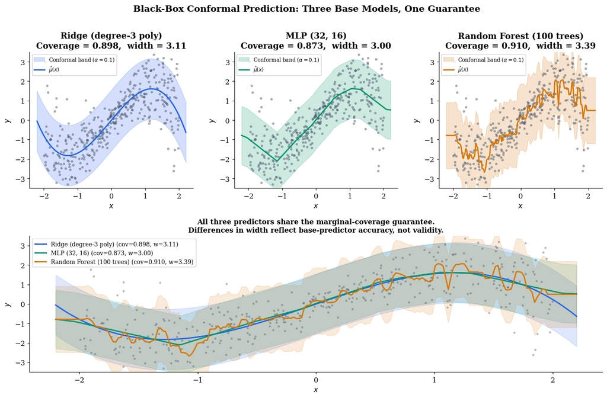

[output not shown]

```python
# === Wrapping Black-Box ML Models ===
# The whole point of conformal prediction's distribution-free guarantee is
# that the base predictor can be anything: ridge, gradient boosting, random
# forest, neural network, transformer. We demonstrate by replacing the
# polynomial-ridge predictor of the earlier cells with two scikit-learn
# black boxes: a feedforward MLP and a random forest. Coverage holds — the
# theorem doesn't care what the predictor is.
#
# The skeleton in 20 lines:
#
#     # Step 1: split data into train / calibration / test.
#     # Step 2: fit any predictor on train.
#     # Step 3: compute |Y_i - mu-hat(X_i)| on calibration; sort.
#     # Step 4: q-hat <- ceil((1-alpha)(n_cal+1))-th smallest.
#     # Step 5: prediction interval = [mu-hat(X_test) - q-hat, mu-hat(X_test) + q-hat].

def fit_predict_mlp(x_train, y_train, x_eval):
    """sklearn MLPRegressor with two hidden layers."""
    rng_local = np.random.RandomState(0)
    model = MLPRegressor(hidden_layer_sizes=(32, 16), max_iter=500,
                          random_state=0, learning_rate_init=0.005)
    model.fit(np.asarray(x_train).reshape(-1, 1), y_train)
    return model.predict(np.asarray(x_eval).reshape(-1, 1))


def fit_predict_rf(x_train, y_train, x_eval):
    """sklearn RandomForestRegressor."""
    model = RandomForestRegressor(n_estimators=100, random_state=0,
                                    min_samples_leaf=5)
    model.fit(np.asarray(x_train).reshape(-1, 1), y_train)
    return model.predict(np.asarray(x_eval).reshape(-1, 1))


# Reuse the heteroscedastic DGP from earlier cells
rng_apps = np.random.default_rng(2026)
n_train_app = 400
n_cal_app = 400
n_test_app = 600
x_all, y_all = synth_heteroscedastic(n_train_app + n_cal_app + n_test_app, rng_apps)
x_tr_app = x_all[:n_train_app]
y_tr_app = y_all[:n_train_app]
x_ca_app = x_all[n_train_app:n_train_app + n_cal_app]
y_ca_app = y_all[n_train_app:n_train_app + n_cal_app]
x_te_app = x_all[-n_test_app:]
y_te_app = y_all[-n_test_app:]

alpha_app = 0.10
predictors = [
    ('Ridge (degree-3 poly)', fit_predict_ridge, BLUE),
    ('MLP (32, 16)', fit_predict_mlp, GREEN),
    ('Random Forest (100 trees)', fit_predict_rf, AMBER),
]

# Coverage / width verification
print(f"Conformal prediction with multiple base predictors  (alpha = {alpha_app})")
print(f"{'predictor':>26}  {'coverage':>10}  {'mean width':>12}  {'q-hat':>8}")
verification_results = []
for name, fn, color in predictors:
    lo, hi, q_hat, _ = split_conformal_interval(
        x_tr_app, y_tr_app, x_ca_app, y_ca_app, x_te_app, alpha_app, fn)
    cov = np.mean((y_te_app >= lo) & (y_te_app <= hi))
    width = np.mean(hi - lo)
    print(f"{name:>26}  {cov:>10.3f}  {width:>12.3f}  {q_hat:>8.3f}")
    verification_results.append((name, fn, color, cov, width, q_hat))

# 4-panel figure: data + bands per predictor + a coverage table
fig = plt.figure(figsize=(16, 9))
gs = gridspec.GridSpec(2, 3, hspace=0.35, wspace=0.25)

x_grid_app = np.linspace(-2.2, 2.2, 200)

for col, (name, fn, color, cov, width, q_hat) in enumerate(verification_results):
    ax = fig.add_subplot(gs[0, col])
    mu_grid = fn(x_tr_app, y_tr_app, x_grid_app)
    ax.fill_between(x_grid_app, mu_grid - q_hat, mu_grid + q_hat, color=color,
                     alpha=0.20, label=f'Conformal band ($\\alpha = {alpha_app}$)')
    ax.plot(x_grid_app, mu_grid, color=color, lw=2, label='$\\hat\\mu(x)$')
    ax.scatter(x_tr_app, y_tr_app, s=8, color=SLATE, alpha=0.4, zorder=1)
    ax.set_xlabel('$x$')
    ax.set_ylabel('$y$')
    ax.set_title(f'{name}\nCoverage = {cov:.3f},  width = {width:.2f}')
    ax.legend(loc='upper left', fontsize=8)
    ax.set_ylim(-3.5, 3.5)

# Bottom row: synthesis panel — all three bands overlaid
ax = fig.add_subplot(gs[1, :])
for name, fn, color, cov, width, q_hat in verification_results:
    mu_grid = fn(x_tr_app, y_tr_app, x_grid_app)
    ax.fill_between(x_grid_app, mu_grid - q_hat, mu_grid + q_hat, color=color,
                     alpha=0.15)
    ax.plot(x_grid_app, mu_grid, color=color, lw=2,
            label=f'{name} (cov={cov:.3f}, w={width:.2f})')
ax.scatter(x_tr_app, y_tr_app, s=6, color=SLATE, alpha=0.3, zorder=1)
ax.set_xlabel('$x$')
ax.set_ylabel('$y$')
ax.set_title('All three predictors share the marginal-coverage guarantee.\n'
             'Differences in width reflect base-predictor accuracy, not validity.',
             fontsize=11)
ax.legend(loc='upper left', fontsize=9)
ax.set_ylim(-3.5, 3.5)

plt.suptitle('Black-Box Conformal Prediction: Three Base Models, One Guarantee',
             fontsize=14, fontweight='bold', y=0.995)
plt.savefig('conformal_blackbox_applications.png', dpi=150,
            bbox_inches='tight', facecolor='white')
plt.show()
print("Figure 9: Conformal prediction wraps any base predictor while preserving the marginal"
      " coverage guarantee. The width depends on the predictor's accuracy; the coverage does not.")
```

## Connections & Further Reading

### Cross-references

[output not shown]

### Notation reference

| Symbol | Meaning |
| --- | --- |
| $(X_i, Y_i)$ | Feature–response pair, $X_i \in \mathcal{X}$, $Y_i \in \mathcal{Y}$. |
| $n_{\text{cal}}$ | Calibration set size. |
| $\alpha \in (0, 1)$ | Miscoverage level; nominal coverage is $1 - \alpha$. |
| $\hat\mu(x)$ | Fitted base predictor (from training data only, in the split case). |
| $s(x, y)$ | Nonconformity score; large = anomalous. |
| $S_i = s(X_i, Y_i)$ | Calibration score at observation $i$. |
| $\hat q_{1-\alpha}$ | Threshold: the $\lceil (1-\alpha)(n_{\text{cal}}+1) \rceil$-th smallest of $\{S_i\}$. |
| $\hat C_\alpha(x)$ | Prediction set: $\{y : s(x, y) \le \hat q_{1-\alpha}\}$. |
| $R_i$ | Leave-one-out residual (jackknife+ / CV+). |
| $\hat q_{\alpha/2}(x), \hat q_{1-\alpha/2}(x)$ | Conditional quantile estimates (CQR base learner). |
| $E_i$ | CQR nonconformity score at observation $i$. |
| $\hat\pi(c \mid x)$ | Predicted softmax probability of class $c$ at input $x$ (APS). |
| $c_{(j)}(x)$ | $j$-th most probable class at $x$. |
| $\rho(y; x)$ | Rank of class $y$ in the descending probability ordering. |

### References

1. Vovk, V., Gammerman, A., & Shafer, G. (2005). *Algorithmic Learning in a Random World*. Springer. — The book that systematized conformal prediction.
2. Lei, J., G'Sell, M., Rinaldo, A., Tibshirani, R. J., & Wasserman, L. (2018). Distribution-free predictive inference for regression. *Journal of the American Statistical Association*, 113(523), 1094–1111. — The marginal-coverage theorem (Theorem 1) and split conformal as the modern default.
3. Romano, Y., Patterson, E., & Candès, E. (2019). Conformalized quantile regression. *Advances in Neural Information Processing Systems*, 32. — CQR (Theorem 3, Cell 6).
4. Romano, Y., Sesia, M., & Candès, E. (2020). Classification with valid and adaptive coverage. *Advances in Neural Information Processing Systems*, 33. — APS (Cell 7).
5. Barber, R. F., Candès, E. J., Ramdas, A., & Tibshirani, R. J. (2021). Predictive inference with the jackknife+. *The Annals of Statistics*, 49(1), 486–507. — Jackknife+ and CV+ (Theorem 2, Cell 5).
6. Foygel Barber, R., Candès, E. J., Ramdas, A., & Tibshirani, R. J. (2021). The limits of distribution-free conditional predictive inference. *Information and Inference*, 10(2), 455–482. — Conditional coverage impossibility (Theorem 4, Cell 8).
7. Tibshirani, R. J., Foygel Barber, R., Candès, E. J., & Ramdas, A. (2019). Conformal prediction under covariate shift. *Advances in Neural Information Processing Systems*, 32. — Importance-weighted conformal prediction.
8. Chernozhukov, V., Wüthrich, K., & Zhu, Y. (2021). Distributional conformal prediction. *Proceedings of the National Academy of Sciences*, 118(48). — Conformal prediction for distributional (full conditional CDF) inference.
9. Vovk, V. (2012). Conditional validity of inductive conformal predictors. *Machine Learning*, 92(2), 349–376. — The original conditional-coverage impossibility statement.